# Multivariate Regression and OLS

EC 325: Econometrics

Prof. Caraher

Colby College

Mar 5, 2026

# From Bivariate to Multivariate OLS

## Where We’ve Been

- Last unit: **bivariate OLS** — one independent variable

$$y = \beta_0 + \beta_1 x + \mu$$

- We learned OLS is **unbiased** when GM assumptions 1–4 are met:
1. **Linear in parameters:** $y = \beta_0 + \beta_1 x + \mu$
2. **Random sampling**
3. **Sample variation in $x$**
4. **Zero conditional mean:** $E[\mu | x] = 0$
- The most important (and hardest to satisfy) is **GM4** — it requires that *everything else* affecting $y$ is uncorrelated with $x$
- That’s a **very strong** assumption — almost never holds in observational data!

## The Problem: A Concrete Example

Consider the effect of education on wages:

$$wage = \beta_0 + \beta_1 \cdot educ + \mu$$

- The error term $\mu$ contains: ability, family connections, motivation, experience, …
- Many of these are **correlated with education**
  - Wealthier families → more education *and* higher wages

**The Core Problem**

If confounders are in $\mu$ and correlated with $x$, then $E[\mu | x] \neq 0$ and $\hat{\beta}_1$ is **biased**.

## Where We’re Going

- **Today:** Multivariate OLS — adding **control variables** to address confounding
- By including variables that might be confounders, we can make the zero conditional mean assumption more plausible

**The Big Question**

How does adding control variables help us get closer to **causal** estimates?

# The Multivariate Model

## The Solution: Control for Confounders

- If family income confounds the education-wage relationship, **include it**:

$$wage = \beta_0 + \beta_1 \cdot educ + \beta_2 \cdot family\_income + \mu$$

- Now $\beta_1$ is the effect of education **holding family income constant**
- Family income is no longer in $\mu$ — that source of bias is gone!

## The General Model

The multivariate linear regression model with $k$ independent variables:

$$y = \beta_0 + \beta_1 x_1 + \beta_2 x_2 + \cdots + \beta_k x_k + \mu$$

where:

- $y$ is the **dependent variable**
- $x_1, x_2, \ldots, x_k$ are the **independent variables**
- $\beta_j$ is the coefficient on $x_j$
- $\mu$ is the error term — now only contains factors **not included** in the model

## Interpreting Coefficients

- Each coefficient has a **ceteris paribus** interpretation:

$$\beta_j = \frac{\partial y}{\partial x_j}$$

- The change in $y$ for a one-unit increase in $x_j$, **holding all other $x$’s constant**
- This is the key difference from bivariate OLS!
  - Bivariate: “associated with” (everything else floating)
  - Multivariate: “holding constant” (controlling for other factors)

## Interpretation Example

$$wage = \beta_0 + \beta_1 \cdot educ + \beta_2 \cdot family\_income + \mu$$

- $\beta_1$: Each additional year of education is associated with $\beta_1$ dollars more in wages, **holding family income constant**
- $\beta_2$: Each additional dollar of family income is associated with $\beta_2$ dollars more in wages, **holding education constant**

## Deriving the Multivariate OLS Estimator

Same logic as bivariate OLS: **minimize the sum of squared residuals**.

$$SSR = \sum_{i=1}^{n} (y_i - \hat{\beta}_0 - \hat{\beta}_1 x_{1i} - \hat{\beta}_2 x_{2i} - \cdots - \hat{\beta}_k x_{ki})^2$$

Taking partial derivatives with respect to each $\hat{\beta}_j$ and setting equal to zero gives $k + 1$ **first-order conditions**:

$$\sum_{i=1}^{n}(y_i - \hat{\beta}_0 - \hat{\beta}_1 x_{1i} - \cdots - \hat{\beta}_k x_{ki}) = 0$$

$$\sum_{i=1}^{n} x_{ji}(y_i - \hat{\beta}_0 - \hat{\beta}_1 x_{1i} - \cdots - \hat{\beta}_k x_{ki}) = 0 \quad \text{for } j = 1, \ldots, k$$

Solving this system yields the OLS estimates. The algebra is tedious (typically handled with matrix methods), but your computer does this effortlessly with `lm()`.

# Multivariate OLS in R

## Adding Controls is Easy!

**🖥️ Try it yourself!**

Same `lm()` function — just use `+` to add variables:

```r
data(mtcars)

# Bivariate: mpg on horsepower
lm_biv <- lm(mpg ~ hp, data = mtcars)

# Multivariate: add weight as control
lm_multi <- lm(mpg ~ hp + wt, data = mtcars)
```

## Comparing Results

**Bivariate:**

```r
summary(lm_biv)
```

```
Call:
lm(formula = mpg ~ hp, data = mtcars)

Residuals:
    Min      1Q  Median      3Q     Max
-5.7121 -2.1122 -0.8854  1.5819  8.2360

Coefficients:
            Estimate Std. Error t value Pr(>|t|)
(Intercept) 30.09886    1.63392  18.421  < 2e-16 ***
hp          -0.06823    0.01012  -6.742 1.79e-07 ***
---
Signif. codes:  0 '***' 0.001 '**' 0.01 '*' 0.05 '.' 0.1 ' ' 1

Residual standard error: 3.863 on 30 degrees of freedom
Multiple R-squared:  0.6024,    Adjusted R-squared:  0.5892
F-statistic: 45.46 on 1 and 30 DF,  p-value: 1.788e-07
```

**Multivariate:**

```r
summary(lm_multi)
```

```
Call:
lm(formula = mpg ~ hp + wt, data = mtcars)

Residuals:
   Min     1Q Median     3Q    Max
-3.941 -1.600 -0.182  1.050  5.854

Coefficients:
            Estimate Std. Error t value Pr(>|t|)
(Intercept) 37.22727    1.59879  23.285  < 2e-16 ***
hp          -0.03177    0.00903  -3.519  0.00145 **
wt          -3.87783    0.63273  -6.129 1.12e-06 ***
---
Signif. codes:  0 '***' 0.001 '**' 0.01 '*' 0.05 '.' 0.1 ' ' 1

Residual standard error: 2.593 on 29 degrees of freedom
Multiple R-squared:  0.8268,    Adjusted R-squared:  0.8148
F-statistic: 69.21 on 2 and 29 DF,  p-value: 9.109e-12
```

- Coefficient on `hp` dropped from **-0.068** to **-0.032** — less than half!
- Why? Horsepower and weight are correlated, and weight independently reduces MPG
- The bivariate estimate was **conflating** the effect of hp with the effect of weight

## Visualizing: The Bivariate View

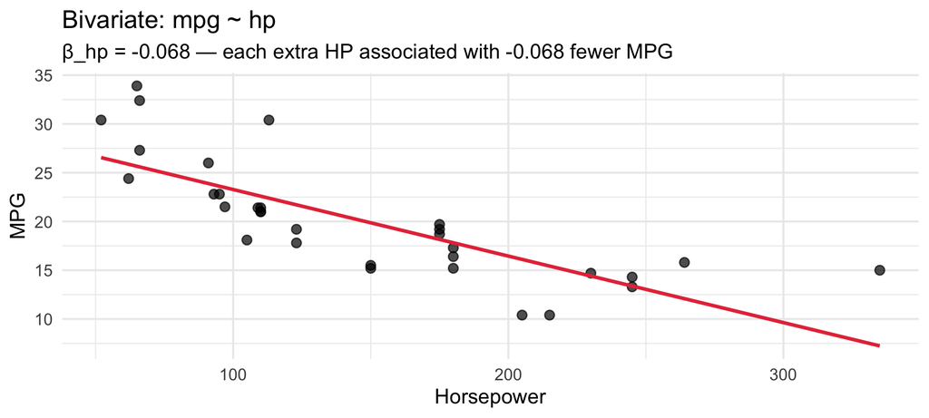

This is the familiar 2D picture — but it ignores weight entirely. Is the slope **too steep** because heavier cars have more HP *and* worse MPG?

## Visualizing: Adding the Third Dimension

[interactive chart not shown]

The dashed red line is the old bivariate fit — it sits flat, ignoring weight. The yellow **plane** accounts for both hp and weight. The hp slope flattened from **-0.068** to **-0.032**.

## Try It: Your First Multivariate Regression

**🖥️ Your turn!**

**Using `mtcars`, estimate a regression of `mpg` on `wt`, `hp`, and `drat` (rear axle ratio). Then answer:**

1. What is the coefficient on `wt`? Interpret it in a sentence.
2. How does the `wt` coefficient compare to a bivariate regression of `mpg ~ wt`?

```r
lm(mpg ~ wt + hp + drat, data = mtcars) |> coef()
```

```
(Intercept)          wt          hp        drat
 29.3949345  -3.2279541  -0.0322304   1.6150485
```

```r
# Compare to bivariate
lm(mpg ~ wt, data = mtcars) |> coef()
```

```
(Intercept)          wt
  37.285126   -5.344472
```

# Multivariate OLS as Matching

## The Intuition

- How does multivariate OLS actually *control* for something? What is going on *under-the-hood*?
- When we “control for” a variable, we’re **comparing like with like**
- Multivariate OLS is essentially a **matching** estimator with three steps:
  1. **Group** observations by the control variable (e.g., occupation)
  2. **Compute averages within each group** and compare $x$ and $y$ **within** each group
  3. **Take a weighted average** of the within-group comparisons across groups
- Think of it as making a bunch of separate “apples-to-apples” comparisons and then aggregating them!

## Example: Gender, Wages, and Occupation

- Let’s construct an imaginary population where we **know the truth**:
- **2,000 workers** who are either Male or Female
- Each worker is in one of two occupations: **Office** or **Manual**
- Women are **more likely** to work in office jobs (70% vs. 40% for men)
- The **true** gender wage gap is **$5,000** (men earn more, holding occupation constant)
- Office jobs pay a **$20,000 premium** over manual jobs (independent of gender)
- Because gender affects *both* wages and occupation sorting, a naive comparison will **understate** the gender gap

## Example: Gender, Wages, and Occupation

```r
set.seed(42)
n <- 2000

wage_data <- tibble(
  female = sample(c(0, 1), n, replace = TRUE),
  # Women more likely to be in office jobs
  office = rbinom(n, 1, prob = ifelse(female == 1, 0.70, 0.40)),
  # True gender gap: -$5000 for women; office premium: $20000
  wage = 30000 - 5000 * female + 20000 * office + rnorm(n, 0, 6000)
) |>
  mutate(gender = ifelse(female == 1, "Female", "Male"),
         occupation = ifelse(office == 1, "Office", "Manual"))
```

## Visualizing the Data in 3D

[interactive chart not shown]

Each cluster is a **gender × occupation cell**. Large markers show the **cell means**. The matching approach compares means within the same occupation (front-to-back).

## The Naive Estimate is Too Small

```r
# Naive: just gender
lm_naive <- lm(wage ~ female, data = wage_data)

# Controlling for occupation
lm_ctrl <- lm(wage ~ female + office, data = wage_data)
```

**Without control:**

```
female
   -13
```

**With occupation control:**

```
female
 -5288
```

- True gap is **-$5,000** — the controlled estimate is much closer!
- Naive estimate was **attenuated** because women sort into higher-paying office jobs, which partially offsets the gap

## Step 1: Compute Within-Group Averages

Compute the average wage for **each gender × occupation cell** — this is the 2×2 table:

```r
cell_means <- wage_data |>
  group_by(occupation, gender) |>
  summarise(avg_wage = mean(wage) |> round(0),
            n = n(), .groups = "drop") |>
  arrange(occupation, gender)

cell_means |> knitr::kable(
  col.names = c("Occupation", "Gender", "Avg Wage ($)", "N"))
```

| Occupation | Gender | Avg Wage ($) | N |
| --- | --- | --- | --- |
| Manual | Female | 24604 | 310 |
| Manual | Male | 29842 | 584 |
| Office | Female | 44931 | 673 |
| Office | Male | 50258 | 433 |

Now we’re comparing men and women **within the same occupation** — apples to apples!

## Step 2: Compute Within-Group Differences

Next, compute the gender wage gap **within each occupation**:

```r
within_diffs <- cell_means |>
  group_by(occupation) |>
  summarise(
    male_wage = avg_wage[gender == "Male"],
    female_wage = avg_wage[gender == "Female"],
    gap = avg_wage[gender == "Female"] - avg_wage[gender == "Male"],
    n_total = sum(n),
    .groups = "drop"
  )

within_diffs |> knitr::kable(
  col.names = c("Occupation", "Male Avg", "Female Avg",
                "Gap (F - M)", "N"),
  digits = 0)
```

| Occupation | Male Avg | Female Avg | Gap (F - M) | N |
| --- | --- | --- | --- | --- |
| Manual | 29842 | 24604 | -5238 | 894 |
| Office | 50258 | 44931 | -5327 | 1106 |

Both within-occupation gaps are **much closer** to the true effect of -$5,000!

## Step 3: Weighted Average Across Groups

Finally, aggregate the within-occupation gaps using a **weighted average**, where the weights reflect each occupation’s share of the sample:

```r
within_diffs <- within_diffs |>
  mutate(weight = n_total / sum(n_total))

within_diffs |>
  select(occupation, gap, weight) |>
  knitr::kable(
    col.names = c("Occupation", "Within-Occ Gap ($)", "Weight"),
    digits = 3)
```

| Occupation | Within-Occ Gap ($) | Weight |
| --- | --- | --- |
| Manual | -5238 | 0.447 |
| Office | -5327 | 0.553 |

```r
# Weighted average of within-occupation gaps
weighted_estimate <- sum(within_diffs$gap * within_diffs$weight)
weighted_estimate |> round(0)
```

```
[1] -5287
```

**Weighted estimate:** -5287 — very close to the true effect of **-$5,000**!

## The Matching Recipe

**What Multivariate OLS Does Under the Hood**

1. **Group** observations by the control variable(s) (e.g., same occupation)
2. **Compare** the outcome across treatment values **within each group** (e.g., the gender wage gap separately for office and manual workers)
3. **Aggregate** with a weighted average across groups (weights = group sizes)

This is exactly what the regression $wage = \beta_0 + \beta_1 \cdot female + \beta_2 \cdot office + \mu$ does — it just automates the process!

```r
# Compare: matching estimate vs regression
c("Matching (weighted avg)" = round(weighted_estimate, 0),
  "Regression" = coef(lm(wage ~ female + office,
                         data = wage_data))["female"] |> round(0),
  "True effect" = -5000)
```

```
Matching (weighted avg)       Regression.female             True effect
                  -5287                   -5288                   -5000
```

# The Zero Conditional Mean Assumption

## The Multivariate Version

- Recall **Gauss-Markov Assumtion 4** which **must hold for our estimate to be unbiased**

$E[\mu | x] = 0$

- All factors contained in $\mu$ must be uncorrelated with $x$
- In multivariate OLS:

$$E[\mu | x_1, x_2, \ldots, x_k] = 0$$

- Everything remaining in $\mu$ must be uncorrelated with **all** included variables
- This is **much more plausible** than the bivariate version — we’ve pulled confounders out of $\mu$!

## When Does the Assumption Hold?

**More plausible when:**

- We include key confounders
- Good theoretical motivation for controls
- Rich set of observable controls

**Less plausible when:**

- Important confounders are unobservable (ability, motivation)
- Wrong functional form

**A Warning**

Adding controls helps but **doesn’t guarantee** causality. Unobservable confounders can always lurk in $\mu$.

# Omitted Variable Bias

## What is Bias?

- **Bias** is the difference between what our estimator gives us *on average* and the *true* parameter value:

$$\text{Bias}(\tilde{\beta}_1) = E[\tilde{\beta}_1] - \beta_1$$

- If $\text{Bias} = 0$, the estimator is **unbiased** — on average, we get the right answer
- If $\text{Bias} \neq 0$, we are **systematically** over- or under-estimating the true effect
- Bias does **not** shrink with more data — it’s a permanent problem!

## The OVB Formula

We want to estimate $\beta_1$. Suppose the **true** model is:

$$y = \beta_0 + \beta_1 x_1 + \beta_2 x_2 + \mu$$

But we omit $x_2$ and estimate:

$$\tilde{y} = \tilde{\beta}_0 + \tilde{\beta}_1 x_1$$

It turns out there is a simple relation between the true value of our parameter, $\beta_1$, an *unbiased* estimate of our parameter $\hat{\beta}_1$, and the *biased* estimate of our parameter $\tilde{\beta}_1$:

$$\tilde{\beta}_1 = \hat{\beta}_1 + \hat{\beta}_2 \cdot \tilde{\delta}_1$$

where $\tilde{\delta}_1$ comes from regressing $x_2$ on $x_1$:

$$\quad x_2 = \tilde{\delta}_0 + \tilde{\delta}_1 x_1$$

## The OVB Formula

- Taking expectations, we see that:

$$E[\tilde{\beta}_1] = E[\hat{\beta}_1 + \hat{\beta}_2 \cdot \tilde{\delta}_1]$$

$$E[\tilde{\beta}_1] = E[\hat{\beta}_1] + E[\hat{\beta}_2] \cdot \tilde{\delta}_1$$

- Since $E[\hat{\beta}_1] = \beta_1$ and $E[\hat{\beta}_2] = \beta_2$:

$$E[\tilde{\beta}_1] = \beta_1 + \beta_2 \cdot \tilde{\delta}_1$$

- Therefore, the bias is:

$$Bias(\tilde{\beta}_1) = E[\tilde{\beta}_1] - \beta_1 = \beta_2 \cdot \tilde{\delta}_1$$

$$\underbrace{Bias(\tilde{\beta}_1)}_{\text{What we get wrong}} = \underbrace{\beta_2}_{\text{Effect of omitted on } y} \times \underbrace{\tilde{\delta}_1}_{\text{Relationship of omitted with } x_1}$$

## Seeing OVB in Action

Let’s **simulate** OVB. We know the true DGP, so we can watch bias appear when we omit a variable:

```r
set.seed(123)
n <- 1000

# True DGP: y = 3 + 2*x1 + 4*x2 + 3*x3 + error
x2 <- rnorm(n)
x3 <- rnorm(n)                    # x3 is independent of x1
x1 <- 0.1 * x2 + rnorm(n)        # x1 and x2 are correlated
y <- 3 + 2 * x1 + 4 * x2 + 3 * x3 + rnorm(n)

# Full model (correct)
coef(lm(y ~ x1 + x2 + x3))["x1"]
```

```
      x1
2.051481
```

```r
# Omit x2 (correlated with x1) — biased!
coef(lm(y ~ x1))["x1"]
```

```
      x1
2.489666
```

```r
# Omit x3 (uncorrelated with x1) — no bias!
coef(lm(y ~ x1 + x2))["x1"]
```

```
      x1
2.138508
```

## Seeing OVB in Action

Omitting $x_2$ (correlated with $x_1$) biases $\hat{\beta}_1$. Omitting $x_3$ (uncorrelated with $x_1$) does **not** — the estimate barely changes!

```r
# Verify: bias from omitting x2 = beta2 * delta1
beta2 <- 4
delta1 <- coef(lm(x2 ~ x1))["x1"]
c(
  "beta2" = beta2,
  "delta1" = delta1,
  "Predicted bias" = beta2 * delta1,
  "Actual bias" = coef(lm(y ~ x1))["x1"] - 2)
```

```
            beta2         delta1.x1 Predicted bias.x1    Actual bias.x1
       4.00000000        0.08262688        0.33050751        0.48966644
```

## Signing the Bias

The bias depends on **two things** — and you can figure out the direction!

|  | $Corr(x_1, x_2) > 0$ | $Corr(x_1, x_2) < 0$ |
| --- | --- | --- |
| $\beta_2 > 0$ | **Positive** bias ↑ | **Negative** bias ↓ |
| $\beta_2 < 0$ | **Negative** bias ↓ | **Positive** bias ↑ |

- Positive × Positive = Positive (overestimate)
- Positive × Negative = Negative (underestimate)

**Zero Bias When…**

If **either** $\beta_2 = 0$ (omitted variable doesn’t affect $y$) **or** $\tilde{\delta}_1 = 0$ (omitted variable uncorrelated with $x_1$), there is **no bias**.

## Example: Positive Bias — Policing and Crime

**True model:** $\quad crime = \beta_0 + \beta_1(police) + \beta_2(poverty) + \mu$

**What we estimate (omitting poverty):** $\quad \widetilde{crime} = \tilde{\beta}_0 + \tilde{\beta}_1(police)$

- **Omitted variable:** poverty
- $\beta_2$ (effect of poverty on crime):
- **Positive** (more poverty → more crime)
- $\tilde{\delta}_1$ (correlation of poverty with policing):
- **Positive** (high-poverty areas → more police)

$$\text{Bias} = (+)(+) = \text{Positive}$$

> The naive estimate makes policing look **less effective** than it actually is (or even that it *increases* crime).

## Example: Negative Bias — Prenatal Care and Birth Weight

**True model:** $\quad birthweight = \beta_0 + \beta_1(prenatal\_visits) + \beta_2(health\_risk) + \mu$

**What we estimate (omitting health risk):** $\quad \widetilde{birthweight} = \tilde{\beta}_0 + \tilde{\beta}_1(prenatal\_visits)$

- **Omitted variable:** maternal health risk
- $\beta_2$ (effect of health risk on birth weight):
- **Negative** (higher risk → lower birth weight)
- $\tilde{\delta}_1$ (correlation of health risk with prenatal visits): **Positive** (higher-risk mothers get *more* prenatal visits)

$$\text{Bias} = (-)(+) = \text{Negative}$$

> The naive estimate **understates** the benefit of prenatal care — high-risk mothers visit more often *and* have worse outcomes, dragging the coefficient toward zero (or even making it negative!).

## Example: Zero Bias — Coffee and Heart Rate

Estimating the effect of coffee consumption on heart rate while omitting height:

$$heart\_rate = \beta_0 + \beta_1(coffee) + \mu$$

- $\beta_2$ (effect of height on heart rate):
- **Negative** — taller people tend to have (slightly) lower resting heart rates
- $\tilde{\delta}_1$ (correlation of height with coffee):
- **Zero** — how tall you are has nothing to do with how much coffee you drink

$$\text{Bias} = (-)(0) = 0$$

> There is **no bias** from omitting height. It fails the second condition: the omitted variable must be correlated with the included regressor. Not every omitted variable is a confounder!

## Class Activity: Sign the Bias!

**🤔 Think-Pair-Share**

For each scenario, determine the **direction** of the omitted variable bias:

1. **Model:** $health = \beta_0 + \beta_1(exercise) + \mu$. Omitted: income.
   - Higher income → more exercise? Higher income → better health?
2. **Model:** $test\_score = \beta_0 + \beta_1(class\_size) + \mu$. Omitted: school funding.
   - More funding → smaller classes? More funding → higher scores?
3. **Model:** $crime = \beta_0 + \beta_1(unemployment) + \mu$. Omitted: urban density.
   - Higher density → more unemployment? Higher density → more crime?

# Goodness of Fit: Adjusted R²

## The Problem with R²

- Recall: $R^2$ measures the fraction of variation in $y$ explained by the model
- **Problem:** $R^2$ can **never decrease** when you add more variables — even irrelevant ones!

```r
# Add 10 completely irrelevant variables
set.seed(42)
noise_data <- mtcars
for (i in 1:10) noise_data[[paste0("noise", i)]] <- rnorm(nrow(mtcars))
noise_vars <- paste0("noise", 1:10)

c("R² without noise" = summary(lm(mpg ~ hp + wt, data = noise_data))$r.squared,
  "R² with noise"    = summary(lm(mpg ~ hp + wt + ., data = noise_data[c("mpg","hp","wt",noise_vars)]))$r.squared)
```

```
R² without noise    R² with noise
       0.8267855        0.8507958
```

- $R^2$ went up even though `random_noise` is meaningless!

## The Fix: Adjusted R²

The **adjusted R-squared** penalizes for the number of variables:

$$\bar{R}^2 = 1 - \frac{(1 - R^2)(n - 1)}{n - k - 1}$$

- where $n$ = number of observations, $k$ = number of regressors, and $(1 - R^2)$ is the share of variance unexplained.
- As $k$ increases, $n - k - 1$ shrinks, making the penalty larger.

```r
c("Adj R² without noise" = summary(lm(mpg ~ hp + wt, data = noise_data))$adj.r.squared,
  "Adj R² with noise"    = summary(lm(mpg ~ hp + wt + ., data = noise_data[c("mpg","hp","wt",noise_vars)]))$adj.r.squared)
```

```
Adj R² without noise    Adj R² with noise
           0.8148396            0.7565616
```

- Adjusted $R^2$ **decreased** — correctly penalizing the irrelevant variable

**Rule of Thumb**

Use **adjusted** $R^2$ when comparing models with different numbers of variables.

# Variance of the Multivariate OLS Estimator

## Extending the Bivariate Result

Recall from the bivariate case:

$$Var(\hat{\beta}_1) = \frac{\sigma^2}{SST_x}$$

Precision comes from **variation in $x$** — more variation means more information about the effect of $x$ on $y$.

In the multivariate case, the same idea applies, but with a twist: **not all variation in $x_j$ is useful**.

- Some variation in $x_j$ is shared with other regressors — OLS can’t tell whether that shared variation is driving $y$ through $x_j$ or through the other controls
- Only the variation in $x_j$ that is **independent of the other regressors** identifies $\hat{\beta}_j$

## How Much Independent Variation Does $x_j$ Have?

Let $R_j^2$ be the R-squared from regressing $x_j$ on all other regressors.

- $R_j^2$ measures how much of $x_j$’s variation is **shared** with the other controls
- $(1 - R_j^2)$ is the fraction that is **independent** — the part that actually identifies $\hat{\beta}_j$

So the effective variation available to estimate $\beta_j$ is:

$$SST_j \times (1 - R_j^2)$$

## Variance of $\hat{\beta}_j$: Result

Replacing $SST_x$ with the residual variation $SST_j(1 - R_j^2)$:

**Variance of the Multivariate OLS Estimator**

$$Var(\hat{\beta}_j) = \frac{\sigma^2}{SST_j(1 - R_j^2)}$$

where $\sigma^2$ is the error variance, $SST_j = \sum(x_{ji} - \bar{x}_j)^2$ is the total variation in $x_j$, and $R_j^2$ is the R-squared from regressing $x_j$ on all other regressors.

Three things **increase** variance: **more noise** ($\sigma^2$ ↑), **less variation in $x_j$** ($SST_j$ ↓), **higher collinearity** ($R_j^2$ ↑)

## What Increases Variance? Simulation

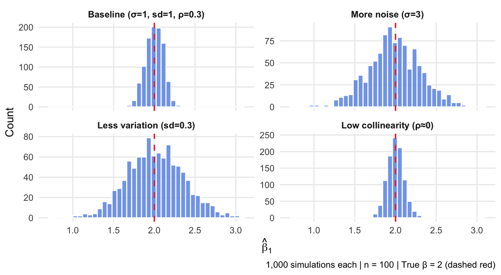

# Assumptions and Multicollinearity

## Gauss-Markov Assumptions (Extended)

The multivariate versions:

1. **Linear in parameters:** $y = \beta_0 + \beta_1 x_1 + \cdots + \beta_k x_k + \mu$
2. **Random sampling**
3. **No perfect multicollinearity** ← UPDATED!
4. **Zero conditional mean:** $E[\mu | x_1, \ldots, x_k] = 0$
5. **Homoskedasticity:** $Var(\mu | x_1, \ldots, x_k) = \sigma^2$

## Perfect Multicollinearity

- New assumption 3 includes both **variation in $x_j$** and **no perfect multicolinearity**
- **Perfect multicollinearity**: one variable is an exact linear function of others

Examples:

- Including `income_dollars` and `income_thousands` (one = other × 1000)
- Including `parent1_income` + `parent2_income` + `family_income` when family = parent1 + parent2

```r
# Create a perfectly collinear variable
mtcars$hp_doubled <- 2 * mtcars$hp
lm(mpg ~ hp + hp_doubled + wt, data = mtcars) |> coef()
```

```
(Intercept)          hp  hp_doubled          wt
37.22727012 -0.03177295          NA -3.87783074
```

- R drops the collinear variable and gives you `NA` — but you should fix the model!

## Imperfect Multicollinearity

- **Imperfect** multicollinearity (high but not perfect correlation) is *allowed* but problematic
- It inflates the **variance** of your estimates:

$$Var(\hat{\beta}_j) = \frac{\sigma^2}{SST_j (1 - R_j^2)}$$

- $R_j^2$ = R-squared from regressing $x_j$ on all other $x$’s
- As $R_j^2 \rightarrow 1$, variance $\rightarrow \infty$
- High correlation between controls makes it hard to **separate their individual effects**
- Your estimates become **imprecise** (large standard errors)

## Visualizing Multicollinearity

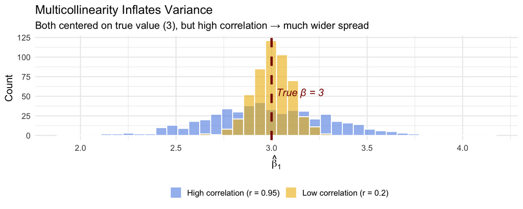

# The Bias-Variance Tradeoff

## Should You Include That Variable?

Adding controls involves a **tradeoff**:

| Action | Bias | Variance |
| --- | --- | --- |
| Omit a **relevant** variable | ↑ Increases | ↓ Decreases |
| Include an **irrelevant** variable | No change | ↑ Increases |

- **Too few controls:** risk bias (omitted variable bias)
- **Too many controls:** risk inflated variance (imprecise estimates)

> Because you can never know *for sure* the true population parameter model, you can never know *for sure* if a control variable is necessary or not!

## Seeing the Tradeoff

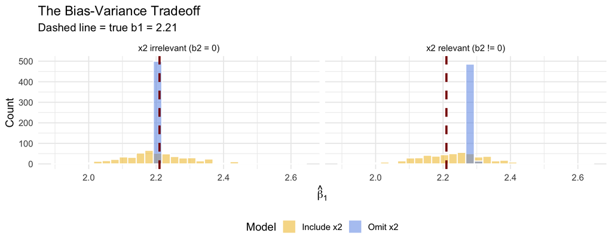

## Reading the Simulation

**Left panel** ($x_2$ irrelevant):

- Both distributions centered on truth → no bias either way
- Including $x_2$ (yellow) is **wider** → unnecessary variance

**Right panel** ($x_2$ relevant):

- Omitting $x_2$ (blue) is **shifted** away from truth → biased!
- Including $x_2$ (yellow) is centered on truth → unbiased (but slightly wider)

**Key Takeaway**

**Bias is usually worse than variance.** A biased estimate is systematically wrong no matter how much data you collect. Extra variance shrinks with larger samples.

## Practical Guidance

**Rules of Thumb for Choosing Controls**

1. **Include** variables you have strong theoretical reason to believe are confounders
2. **Be cautious** with highly correlated controls — can inflate variance dramatically
3. **Larger samples help** — variance decreases with $n$, so the cost of extra controls falls
4. **Check sensitivity** — if adding a control substantially changes your coefficient of interest, it’s probably important

# Summary

## Key Takeaways

- **Multivariate OLS** includes control variables to address confounding:

$$y = \beta_0 + \beta_1 x_1 + \beta_2 x_2 + \cdots + \beta_k x_k + \mu$$

- Coefficients have **ceteris paribus** interpretations: the effect of $x_j$ holding all else constant
- **OVB formula** tells us the direction of bias: $\text{Bias} = \beta_2 \cdot \tilde{\delta}_1$
- **Bias-variance tradeoff:** omitting relevant variables → bias; including irrelevant variables → extra variance
- **Adjusted R²** penalizes for extra variables — use it for model comparison
- **Perfect multicollinearity** breaks OLS; imperfect multicollinearity inflates variance

## What’s Next?

- **Unit 6:** Statistical Inference — hypothesis testing and confidence intervals for regression coefficients
- We’ll finally be able to answer: “Is this coefficient **statistically significant**?”

EC325 | Unit 5 | Multivariate Regression and OLS